# RNA-seq reanalysis of lung tissue in COPD versus control subjects (GSE57148)

Reanalysis of Kim et al. 2015, Int J Genomics

Group 9

May 13, 2026

# 1 Introduction

The dataset analyzed in this report comes from Kim et al. (2015, *International Journal of Genomics*), available on GEO under accession GSE57148. The authors used RNA-seq to compare lung tissue from patients with chronic obstructive pulmonary disease (COPD) against tissue from controls with normal lung function, with the goal of identifying biological pathways that are dysregulated in the disease.

COPD is a common, progressive lung disease characterized by mostly irreversible airflow obstruction. It is diagnosed when the post-bronchodilator FEV1/FVC ratio falls below 0.7. The molecular mechanisms behind the disease are still not fully understood. Current models point to chronic airway inflammation sustained by oxidative stress, an imbalance between proteinases and their inhibitors, accelerated apoptosis of alveolar cells, and epigenetic dysregulation. Transcriptomic profiling of lung tissue is a useful way to investigate these mechanisms, since it can simultaneously pick up signatures of inflammation, mitochondrial dysfunction, defects in protein turnover and chromatin-level changes.

In their analysis, Kim et al. reported 2,312 differentially expressed genes between COPD and control samples, with the strongest enrichments in oxidative phosphorylation, protein catabolism through the ubiquitin-proteasome system, and chromatin modification. The aim of this report is to reproduce the analysis of GSE57148 using techniques learned in the NGS course, and to check whether the original conclusions are replicated. We follow the same overall workflow as in the practical labs, which includes exploratory data analysis, normalization, differential expression and gene-set analysis. We also add two Bioconductor packages on top. The first is DESeq2, run alongside edgeR to confirm that any signal we find is not an artifact of one particular test. The second is simplifyEnrichment, used to cluster the redundant Gene Ontology terms returned by enrichment analysis into a smaller number of interpretable themes.

Our objective is to address several questions. First, whether our pipeline recovers the gene-level signature reported by Kim et al. Second, whether edgeR and DESeq2 give consistent results. Third, whether the same three pathway families (mitochondrial energy metabolism, proteostasis and chromatin regulation) emerge from our independent enrichment analyzes. And finally, whether the simplifyEnrichment summary matches the paper’s biological story.

# 2 Methodology of Kim et al. (2015)

Subjects were recruited from the Asan Biobank between January 2008 and November 2011, all undergoing surgical resection for lung cancer. Inclusion required a post-bronchodilator FEV1/FVC ratio below 0.7 for the COPD group and normal spirometry for the control group, following the American Thoracic Society / European Respiratory Society criteria. The final cohort was 98 COPD patients and 91 controls, all male and all current or former smokers, with the COPD group on average older and with more pack-years of smoking. Total RNA was extracted from histologically normal frozen tissue taken distal to the cancer lesion, with integrity and purity checked on an Agilent Bioanalyzer and a NanoDrop spectrophotometer.

For library preparation, 1 µg of total RNA was processed with the Illumina TruSeq RNA library kit (poly-A selection, fragmentation, reverse transcription with random hexamer primers). The cDNA libraries were sequenced as 100 bp paired-end reads on an Illumina HiSeq 2000, producing on average 38.7 million reads per sample, with no significant difference between groups. The protocol, sample annotations and raw data were deposited on NCBI GEO under accession GSE57148, and the metadata meet the MIAME requirements.

On the computational side, read quality was checked with FastQC. Reads were aligned to the UCSC hg19 genome with TopHat (v1.4.1) and quantified with Cufflinks (v2.0.0) as FPKM (fragments per kilobase of exon per million mapped fragments), which normalizes by gene length and sequencing depth. Genes with an FPKM of zero across all samples were removed, along with non-coding and low-variance genes, leaving 16,676 for analysis. The remaining values were upper-quartile normalized, and differential expression was tested with a Student’s t-test followed by Benjamini-Hochberg correction, yielding 2,312 DEGs at q < 0.01.

For functional interpretation, the authors combined three tools: GSEA (v2.0.8) with gene sets from MSigDB for pathway enrichment, DAVID (v6.7) for GO term enrichment, and BioLattice (v1.1) to visualize relationships between coexpressed gene clusters and GO terms. The paper also includes differential isoform analysis with Cufflinks, alternative splicing analysis with MATS, and a Connectivity Map query for candidate drugs that reverse the COPD signature, though these are not reproduced in the present work. Seven DEGs were validated by qRT-PCR with results that agreed well with the RNA-seq fold changes.

# 3 Our computational pipeline and results

## 3.1 Pipeline overview

The full analysis comprises the following steps, summarized in Table 1 below. Each row corresponds to a section of this report.

| Step | Method / Package | Purpose | Key output |
| --- | --- | --- | --- |
| 1. Data import | `SummarizedExperiment` | Bundle counts, annotation, metadata | 39,376 genes × 184 samples |
| 2. Filtering | rowSums + GeneType | Drop low-count and non-coding genes | 16,663 protein-coding genes |
| 3. EDA | boxplot, RLE, PCA | Detect batch effects, library-size imbalance | Partial PCA separation, RLE shift |
| 4. Normalization | TMM (`edgeR`) | Correct compositional bias | RLE medians at 0 after normalization |
| 5. DE testing (primary) | NB-GLM + LRT (`edgeR`) | Identify DEGs | 8,255 DEGs at FDR < 0.05 |
| 6. DE testing (cross-check) | NB-GLM + Wald (`DESeq2`) | Confirm robustness across methods | 8,307 DEGs, 96% overlap with edgeR |
| 7. Pathway ORA | `clusterProfiler`, `ReactomePA` | Test pathway over-representation on DEGs | KEGG, Reactome, GO BP hits |
| 8. Pathway GSEA | `clusterProfiler` (KEGG, GO BP) | Test coordinated changes across ranked gene list | 84 KEGG, 850 GO BP pathways |
| 9. GO summarization | `simplifyEnrichment` (added value) | Cluster redundant GO terms semantically | 12 thematic clusters |
| 10. Comparison with paper | Custom gene-list lookup | Verify recovery of Kim et al.’s top genes | Direction of change matches |

## 3.2 Setup

Unlike Kim et al., we did not perform read alignment ourselves. The dataset was downloaded from NCBI as a pre-computed gene-level count matrix, with reads re-aligned to the GRCh38.p13 reference genome and quantified at the gene level by NCBI. This means our analysis starts from integer counts rather than from FASTQ files, which is the standard input format for the count-based statistical methods used in the practical labs. Three input files were used: the recount counts matrix, an NCBI annotation table linking Entrez gene IDs to gene symbols and gene types, and the GEO series matrix file from which sample-level metadata were parsed.

```r
suppressPackageStartupMessages({
  library(dplyr)
  library(ggplot2)
  library(ggrepel)
  library(ggfortify)
  library(pheatmap)
  library(RColorBrewer)
  library(SummarizedExperiment)
  library(edgeR)
  library(limma)
  library(EDASeq)
  library(genefilter)
  library(DESeq2)
  library(clusterProfiler)
  library(org.Hs.eg.db)
  library(ReactomePA)
  library(enrichplot)
  library(simplifyEnrichment)
  library(cluster)
  library(knitr)
})
```

```r
data_dir <- "."

counts_file <- file.path(data_dir, "GSE57148_raw_counts_GRCh38_p13_NCBI.tsv")
annot_file  <- file.path(data_dir, "Human_GRCh38_p13_annot.tsv")
series_file <- file.path(data_dir, "GSE57148_series_matrix.txt")
```

## 3.3 Data import and exploratory analysis

The recount counts matrix contains 39,376 genes across 184 samples. Sample-level metadata were parsed from the GEO series matrix file, giving a final cohort of 89 controls and 95 COPD samples. This is slightly fewer than the 91 + 98 reported in the paper, because a small number of samples were not re-quantified by NCBI when GSE57148 was processed into the recount-style format. Group balance is preserved.

```r
counts_df <- read.delim(counts_file, header = TRUE, check.names = FALSE,
                        stringsAsFactors = FALSE)
rownames(counts_df) <- as.character(counts_df$GeneID)
counts_mat <- as.matrix(counts_df[, -1])
storage.mode(counts_mat) <- "integer"

dim(counts_mat)
```

```
## [1] 39376   184
```

```r
counts_mat[1:5, 1:4]
```

```
##           GSM1375986 GSM1375987 GSM1375988 GSM1375989
## 100287102          0          1          1          3
## 653635           245        245        301        529
## 102466751         14         19         22         45
## 107985730          0          0          0          0
## 100302278          0          0          0          0
```

```r
annot <- read.delim(annot_file, header = TRUE, check.names = FALSE,
                    stringsAsFactors = FALSE, quote = "")
annot$GeneID <- as.character(annot$GeneID)

annot <- annot[match(rownames(counts_mat), annot$GeneID), ]

head(annot[, c("GeneID", "Symbol", "GeneType", "EnsemblGeneID", "Length")])
```

```
##      GeneID      Symbol GeneType   EnsemblGeneID Length
## 1 100287102     DDX11L1   pseudo ENSG00000290825   1652
## 2    653635      WASH7P   pseudo                   1769
## 3 102466751   MIR6859-1    ncRNA ENSG00000278267     68
## 4 107985730 MIR1302-2HG    ncRNA                    538
## 5 100302278   MIR1302-2    ncRNA ENSG00000284332    138
## 6    645520     FAM138A    ncRNA ENSG00000237613   1130
```

```r
table(annot$GeneType)
```

```
##
##                         ncRNA          other protein-coding         pseudo
##           1610          15480            388          19416           1392
##           rRNA          scRNA         snoRNA          snRNA           tRNA
##             39              4            541             63            437
##        unknown
##              6
```

```r
lines <- readLines(series_file)

geo_ids <- strsplit(grep("^!Sample_geo_accession", lines, value = TRUE),
                    "\t", fixed = TRUE)[[1]][-1]
geo_ids <- gsub('"', '', geo_ids, fixed = TRUE)

titles <- strsplit(grep("^!Sample_title", lines, value = TRUE),
                   "\t", fixed = TRUE)[[1]][-1]
titles <- gsub('"', '', titles, fixed = TRUE)

ch_lines <- grep("^!Sample_characteristics_ch1", lines, value = TRUE)
disease_row <- ch_lines[grepl("disease state", ch_lines)][1]
disease <- strsplit(disease_row, "\t", fixed = TRUE)[[1]][-1]
disease <- gsub('"', '', disease, fixed = TRUE)
disease <- sub("^disease state: ", "", disease)

samples <- data.frame(
  sample_id = geo_ids,
  title     = titles,
  disease   = factor(disease, levels = c("Normal", "COPD")),
  stringsAsFactors = FALSE
)
samples <- samples[match(colnames(counts_mat), samples$sample_id), ]

table(samples$disease)
```

```
##
## Normal   COPD
##     89     95
```

The counts matrix, annotation table and sample metadata were bundled into a `SummarizedExperiment` object, which keeps all three components aligned so that subsetting operations propagate consistently. Two filtering steps were then applied. First, low-count genes were removed using the threshold of at least 10 counts in at least 10 samples (the standard threshold from the practical labs), leaving 23,632 genes. Second, the matrix was restricted to protein-coding genes to match Kim et al.’s filtering, leaving **16,663 genes** for downstream analysis, almost identical to the 16,676 reported in the paper.

```r
se <- SummarizedExperiment(
  assays  = list(counts = counts_mat),
  rowData = DataFrame(annot),
  colData = DataFrame(samples, row.names = samples$sample_id)
)
se
```

```
## class: SummarizedExperiment
## dim: 39376 184
## metadata(0):
## assays(1): counts
## rownames(39376): 100287102 653635 ... 4576 4571
## rowData names(18): GeneID Symbol ... GOProcess GOComponent
## colnames(184): GSM1375986 GSM1375987 ... GSM1376173 GSM1376174
## colData names(3): sample_id title disease
```

```r
keep <- rowSums(assay(se, "counts") >= 10) >= 10
table(keep)
```

```
## keep
## FALSE  TRUE
## 15744 23632
```

```r
se <- se[keep, ]
dim(se)
```

```
## [1] 23632   184
```

```r
coding_idx <- rowData(se)$GeneType == "protein-coding"
table(coding_idx, useNA = "ifany")
```

```
## coding_idx
## FALSE  TRUE
##  6969 16663
```

```r
se <- se[coding_idx, ]
dim(se)
```

```
## [1] 16663   184
```

Library sizes ranged from about 14 to 35 million reads per sample (median 17.2 million) and were comparable across groups (Figure 1), confirming that sequencing depth is not a confounder of the disease contrast.

```r
libsize <- colSums(assay(se, "counts"))
summary(libsize)
```

```
##     Min.  1st Qu.   Median     Mean  3rd Qu.     Max.
## 14053415 15727007 17208262 17605862 18680164 35025982
```

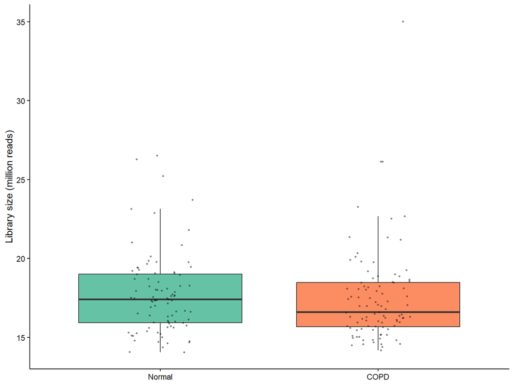

**Figure 1.** Library size by group. Boxplots of total mapped reads per sample, in millions, separated by disease status. The two groups have comparable depth, with no systematic imbalance that could confound the comparison.

```r
ggplot(data.frame(libsize = libsize / 1e6, disease = se$disease),
       aes(x = disease, y = libsize, fill = disease)) +
  geom_boxplot(outlier.shape = NA) +
  geom_jitter(width = 0.15, alpha = 0.4, size = 0.6) +
  labs(y = "Library size (million reads)", x = NULL) +
  scale_fill_brewer(palette = "Set2") +
  theme_classic() +
  theme(legend.position = "none")
```

The boxplots of log-transformed counts before normalization (Figure 2) showed visibly different medians and interquartile ranges across samples, and the relative log expression (RLE) plot (Figure 3) confirmed this with several samples showing inflated IQRs and non-zero medians. This is the textbook pattern that motivates between-sample normalization.

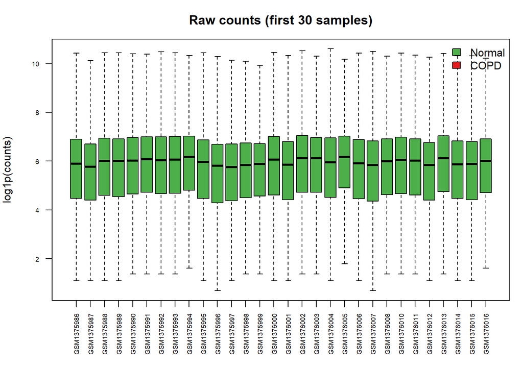

**Figure 2.** Distribution of log-transformed raw counts in the first 30 samples, colored by disease status. Several samples show visibly shifted medians, indicating that between-sample normalization is needed before downstream analysis.

```r
raw_counts <- assay(se, "counts")

grp_colors <- c(Normal = "#4DAF4A", COPD = "#E41A1C")
col_vec    <- grp_colors[as.character(se$disease)]

op <- par(mar = c(7, 4, 3, 1))
boxplot(log1p(raw_counts)[, 1:30],
        col = col_vec[1:30], outline = FALSE, las = 2, cex.axis = 0.6,
        ylab = "log1p(counts)", main = "Raw counts (first 30 samples)")
legend("topright", fill = grp_colors, legend = names(grp_colors), bty = "n")
```

```r
par(op)
```

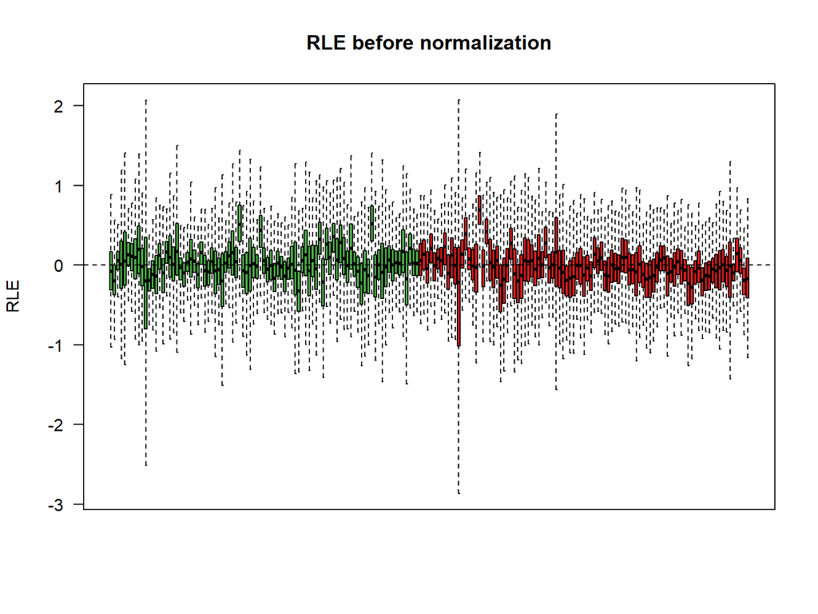

**Figure 3.** Relative log expression (RLE) plot before normalization. Each box represents one sample, with the center line indicating the median deviation from a reference computed across all samples. The visible non-zero medians and inflated IQRs across many samples confirm the need for normalization.

```r
EDASeq::plotRLE(raw_counts, outline = FALSE, las = 2,
                col = col_vec, main = "RLE before normalization",
                ylab = "RLE", xaxt = "n")
abline(h = 0, lty = 2)
```

Principal component analysis on the log-transformed raw counts (Figure 4) showed partial separation of the two groups, with PC1 capturing about 17% of the variance and PC2 about 10%. The two groups overlap considerably, which is consistent with what Kim et al. reported: the COPD signal is real but moderate, distributed across many genes with small effect sizes rather than a single sharp axis.

```r
pca_raw <- prcomp(t(log1p(raw_counts)))
var_exp <- summary(pca_raw)$importance[2, 1:10]
round(var_exp, 3)
```

```
##   PC1   PC2   PC3   PC4   PC5   PC6   PC7   PC8   PC9  PC10
## 0.171 0.100 0.086 0.075 0.044 0.036 0.025 0.021 0.018 0.018
```

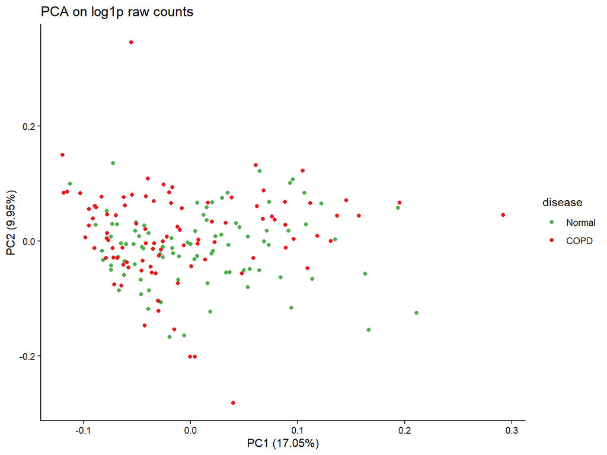

**Figure 4.** PCA on log-transformed raw counts. Samples are colored by disease status. PC1 and PC2 explain about 17% and 10% of the variance respectively, with partial but incomplete separation of the two groups.

```r
autoplot(pca_raw, data = as.data.frame(colData(se)), color = "disease") +
  scale_color_manual(values = grp_colors) +
  ggtitle("PCA on log1p raw counts") +
  theme_classic()
```

## 3.4 Normalization

We used TMM normalization from edgeR, which is the standard pairing with negative-binomial GLM testing. TMM works at the level of library scaling factors: the original raw counts are retained, and the scaling factors are passed to the GLM as an offset. This avoids double normalization and ensures that the statistical test sees the actual count structure. The CPM matrix produced afterwards is used only for visualization (heatmaps, PCA), not for testing.

```r
dge <- DGEList(counts = raw_counts, group = se$disease)
dge <- calcNormFactors(dge, method = "TMM")
summary(dge$samples$norm.factors)
```

```
##    Min. 1st Qu.  Median    Mean 3rd Qu.    Max.
##  0.8286  0.9721  1.0088  1.0017  1.0396  1.1531
```

```r
tmm_cpm <- cpm(dge, normalized.lib.sizes = TRUE)
log_tmm <- cpm(dge, log = TRUE, prior.count = 1)
```

The TMM scaling factors ranged from 0.83 to 1.15 (median ≈ 1.01), within the typical range for RNA-seq data. After normalization, the RLE distributions (Figure 6) are centered at zero and visibly tighter than before, confirming that compositional bias has been removed. The boxplots in Figure 5 show the same effect on the per-sample distributions.

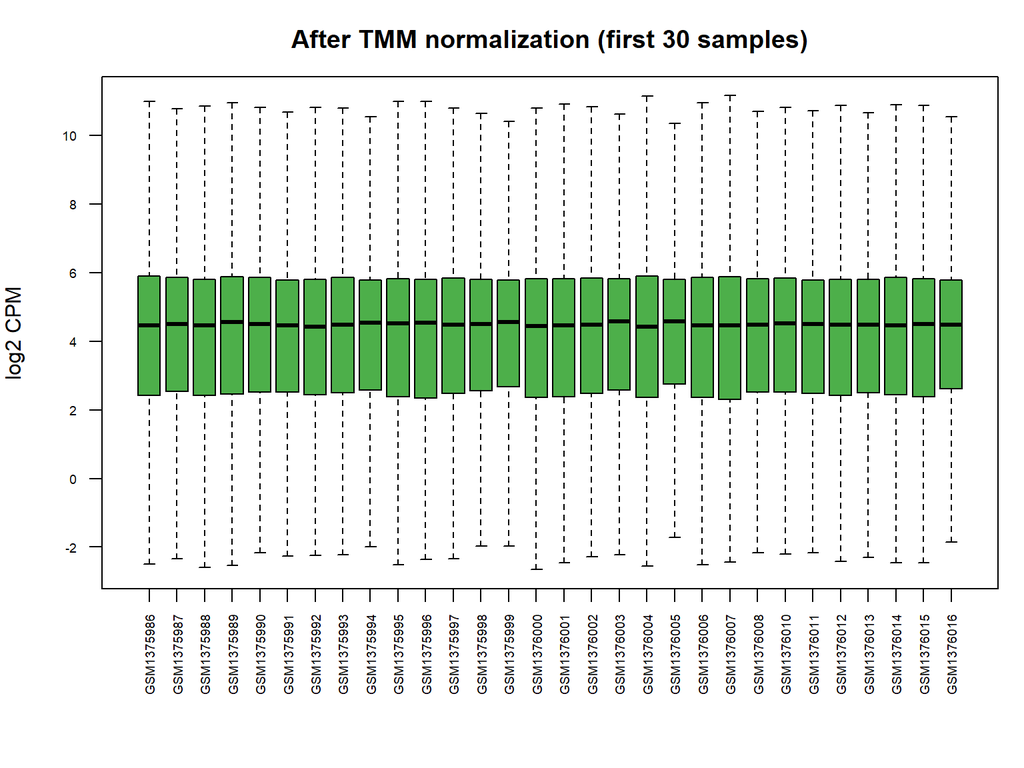

**Figure 5.** Per-sample distributions after TMM normalization (first 30 samples). The medians are now aligned across samples, in contrast to the pre-normalization distributions in Figure 2.

```r
op <- par(mar = c(7, 4, 3, 1))
boxplot(log_tmm[, 1:30],
        col = col_vec[1:30], outline = FALSE, las = 2, cex.axis = 0.6,
        ylab = "log2 CPM", main = "After TMM normalization (first 30 samples)")
```

```r
par(op)
```

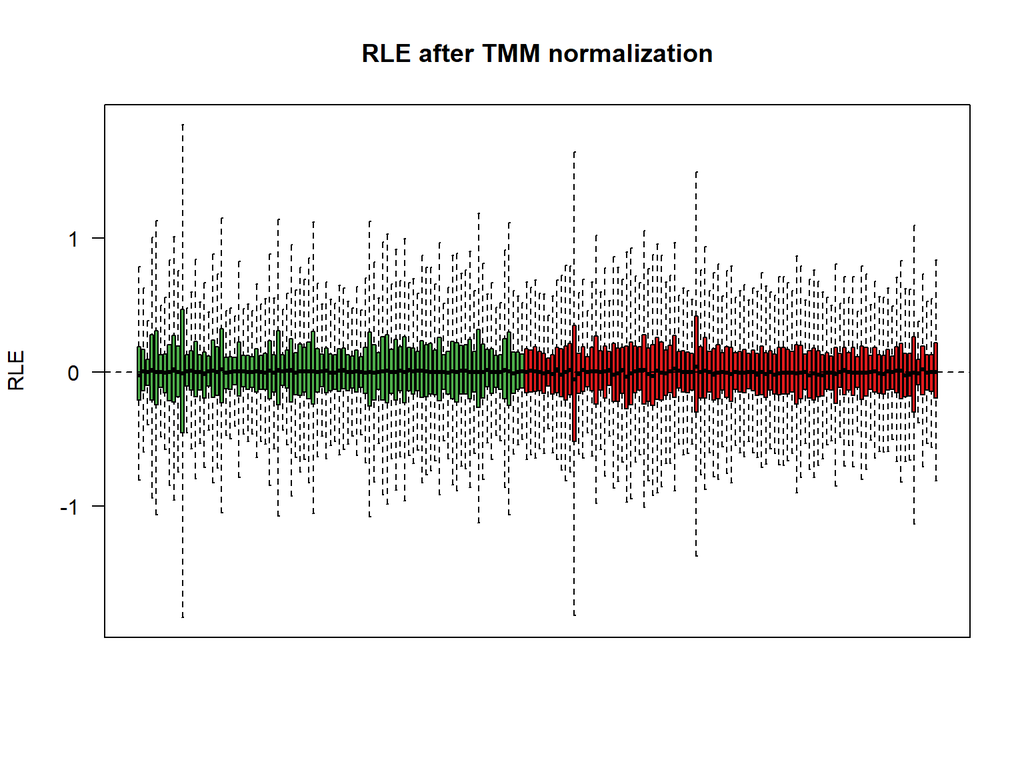

**Figure 6.** Relative log expression (RLE) plot after TMM normalization. Medians are now centered at zero across all samples, and interquartile ranges are visibly tighter than before normalization (compare with Figure 3), confirming that TMM has corrected for compositional differences between libraries.

```r
EDASeq::plotRLE(tmm_cpm, outline = FALSE, las = 2,
                col = col_vec, main = "RLE after TMM normalization",
                ylab = "RLE", xaxt = "n")
abline(h = 0, lty = 2)
```

PCA on the TMM-normalized log-CPM matrix (Figure 7) gave a similar picture to the raw-count PCA: partial separation between COPD and control along the first two PCs, with PC1 and PC2 capturing 17.5% and 9.5% of the variance respectively. The fact that the structure barely changes after normalization is reassuring; it means the biological signal we will detect downstream is not an artifact of library-composition differences.

```r
pca_tmm <- prcomp(t(log_tmm))
var_exp_tmm <- summary(pca_tmm)$importance[2, 1:10]
round(var_exp_tmm, 3)
```

```
##   PC1   PC2   PC3   PC4   PC5   PC6   PC7   PC8   PC9  PC10
## 0.175 0.095 0.083 0.065 0.042 0.028 0.024 0.020 0.019 0.017
```

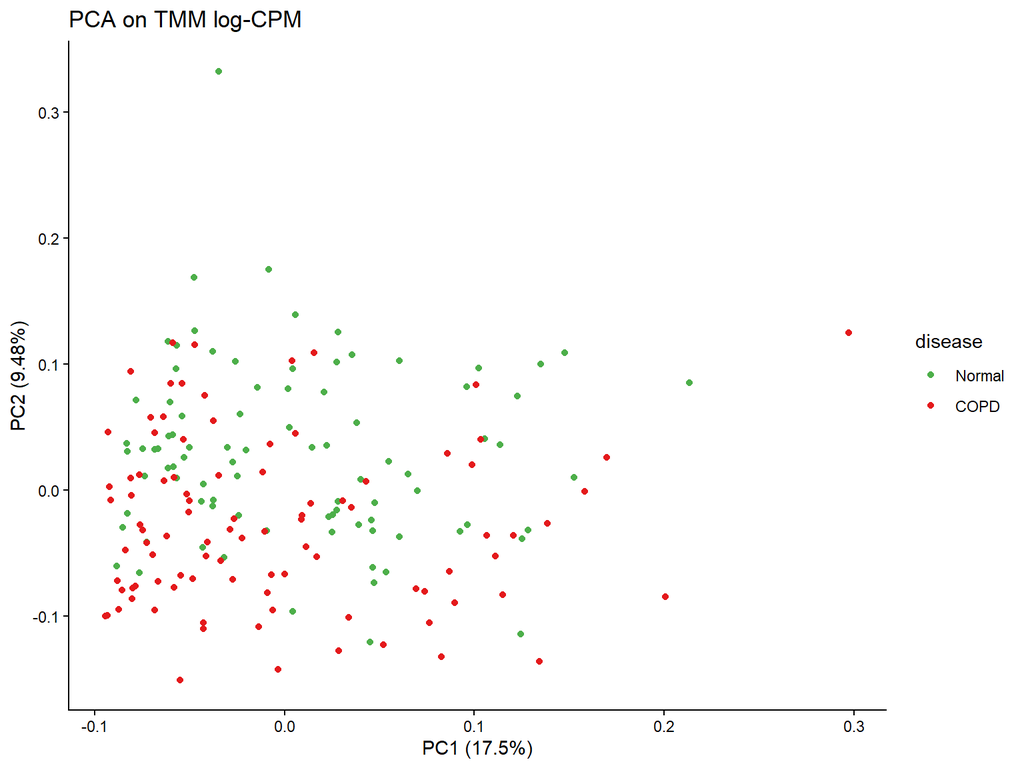

**Figure 7.** PCA on TMM-normalized log-CPM. PC1 and PC2 explain 17.5% and 9.5% of the variance. The partial separation of COPD and control samples is similar to that seen on raw counts (Figure 4), confirming the signal is biological rather than technical.

```r
autoplot(pca_tmm, data = as.data.frame(colData(se)), color = "disease") +
  scale_color_manual(values = grp_colors) +
  ggtitle("PCA on TMM log-CPM") +
  theme_classic()
```

## 3.5 Differential expression with edgeR

Differential expression was tested with the negative-binomial GLM in edgeR, using disease as the only covariate. The model fits a gene-wise dispersion to capture the count variance structure, then uses a likelihood-ratio test to compare the COPD coefficient against zero. The BCV plot (Figure 8) showed the typical pattern of decreasing dispersion with expression, flattening at higher expression around a biological coefficient of variation of approximately 0.3, which is typical for human tissue samples.

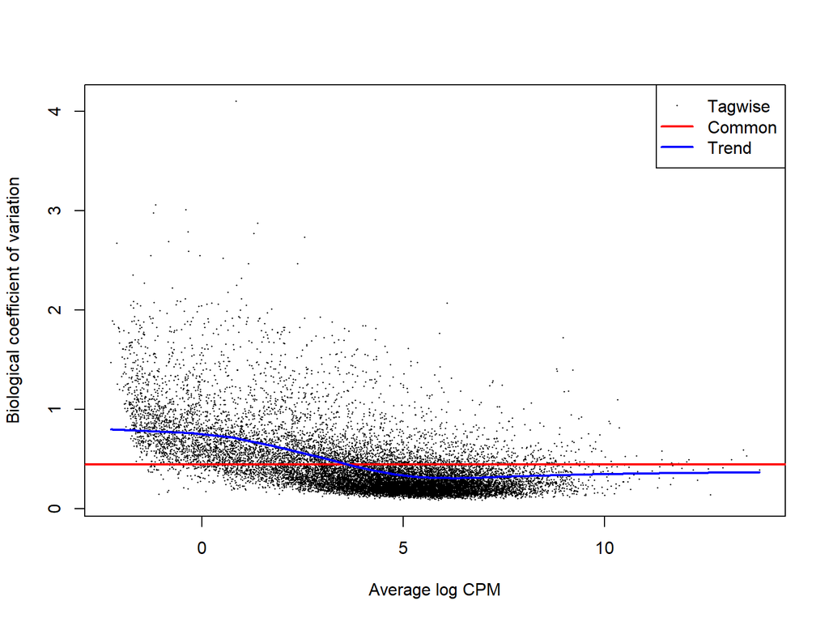

**Figure 8.** Biological coefficient of variation (BCV) plot from edgeR. The trended dispersion line decreases with average log-CPM and flattens at higher expression around BCV ≈ 0.3, which is the expected pattern for human tissue data. Outlier high-BCV genes are mostly low-expression.

```r
design <- model.matrix(~ disease, data = colData(se))
colnames(design)[2] <- "COPDvsNormal"

dge <- estimateDisp(dge, design)
plotBCV(dge)
```

```r
fit <- glmFit(dge, design)
res <- glmLRT(fit, coef = "COPDvsNormal")

tab <- topTags(res, n = Inf)$table
tab$Symbol <- rowData(se)$Symbol[match(rownames(tab), rowData(se)$GeneID)]
head(tab[order(tab$PValue), c("Symbol", "logFC", "logCPM", "LR", "PValue", "FDR")], 15)
```

```
##         Symbol      logFC    logCPM        LR       PValue          FDR
## 440695   ETV3L  1.4817825 -0.366508 140.68470 1.885772e-32 3.142262e-28
## 23352     UBR4  0.4787419  7.621807 124.55005 6.384837e-29 5.319527e-25
## 23112   TNRC6B  0.4487565  6.439310 112.00674 3.560974e-26 1.977884e-22
## 55209    SETD5  0.3005770  7.265509 104.62700 1.474338e-24 6.141723e-21
## 6827   SUPT4H1 -0.3643543  5.118591 103.64433 2.420995e-24 8.068207e-21
## 8924     HERC2  0.4585506  6.750533 101.64720 6.634546e-24 1.630919e-20
## 441531   PGAM4 -0.6872959  1.392212 101.58350 6.851367e-24 1.630919e-20
## 11340   EXOSC8 -0.3979414  4.769981 100.28140 1.322128e-23 2.753826e-20
## 23013     SPEN  0.5459162  7.179532  98.17133 3.837059e-23 7.104101e-20
## 23633    KPNA6  0.3260393  6.560214  96.98966 6.969018e-23 1.161248e-19
## 56984    PSMG2 -0.3407378  5.253929  95.85462 1.236369e-22 1.872875e-19
## 1337    COX6A1 -0.4731864  5.997306  94.02294 3.118876e-22 4.330820e-19
## 1778   DYNC1H1  0.4909550  8.300924  93.02382 5.166870e-22 6.622735e-19
## 6942     TCF20  0.3967821  5.781045  92.60042 6.399393e-22 7.616649e-19
## 4297     KMT2A  0.4973706  6.727234  91.42846 1.157003e-21 1.285276e-18
```

At an FDR threshold of 0.05, edgeR identified **8,255 differentially expressed genes**, with a near-even split between up- and down-regulation in COPD (4,001 up, 4,254 down). At the more stringent threshold of FDR < 0.01 used in the original paper, we still recovered **6,389 DEGs**, substantially more than the 2,312 reported by Kim et al. The reasons for this difference are discussed below.

```r
deg_05 <- tab[tab$FDR < 0.05, ]
deg_01 <- tab[tab$FDR < 0.01, ]
cat(sprintf("DEGs at FDR < 0.05: %d\n", nrow(deg_05)))
```

```
## DEGs at FDR < 0.05: 8255
```

```r
cat(sprintf("DEGs at FDR < 0.01: %d\n", nrow(deg_01)))
```

```
## DEGs at FDR < 0.01: 6389
```

```r
cat(sprintf("Up-regulated in COPD   (logFC > 0): %d\n", sum(deg_05$logFC > 0)))
```

```
## Up-regulated in COPD   (logFC > 0): 4001
```

```r
cat(sprintf("Down-regulated in COPD (logFC < 0): %d\n", sum(deg_05$logFC < 0)))
```

```
## Down-regulated in COPD (logFC < 0): 4254
```

The top hits include several genes prominently reported by Kim et al., including **UBR4** (ubiquitin protein ligase, paper rank 2), **SETD5** (paper rank 19), **HERC2** (paper rank 7), **SPEN** (paper rank 6), **KPNA6** (paper rank 3), **TCF20** (paper rank 9) and **COX6A1** (paper rank 11). Direction of change agrees with the paper in all cases. Two strong hits in our analysis that did not appear in the paper’s top-20 are **ETV3L** (logFC ≈ +1.48, the strongest signal in our top table) and **TNRC6B**, both of which the original t-test on FPKM appears to have missed.

The MD plot and volcano plot (Figure 9) show DEGs distributed symmetrically around logFC = 0, with no obvious global up- or down-shift, which is the expected pattern for a well-controlled differential expression analysis. The p-value histogram (Figure 10) has the textbook shape of a flat uniform component from non-DE genes plus a strong peak near zero from true positives, indicating that the test is well-calibrated.

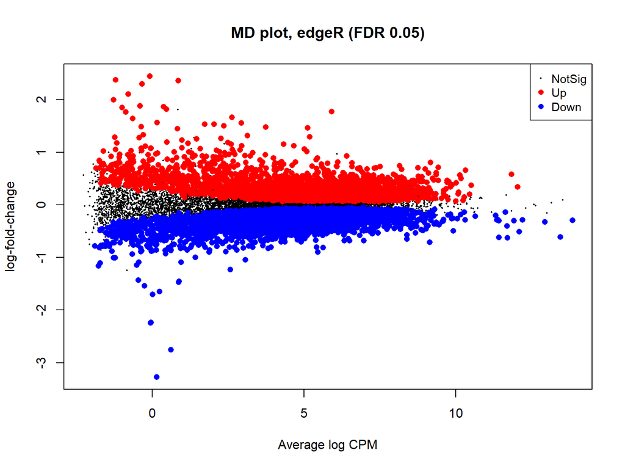

```r
plotMD(res, status = decideTests(res, p.value = 0.05),
       main = "MD plot, edgeR (FDR 0.05)")
```

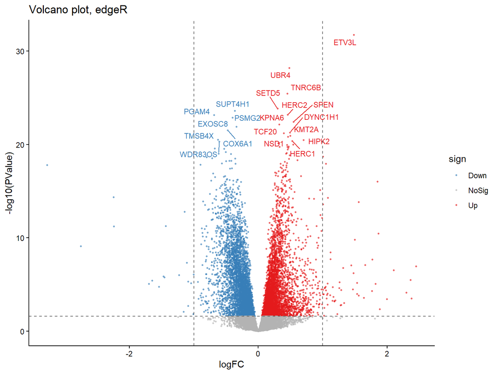

**Figure 9.** Volcano plot of edgeR differential expression results. Genes are colored by significance and direction (red = up in COPD, blue = down). The horizontal dashed line marks the FDR < 0.05 threshold. The top 20 most significant DEGs are labeled with gene symbols. The split between up- and down-regulated genes is roughly even.

```r
tab$sign <- "NoSig"
tab$sign[tab$FDR < 0.05 & tab$logFC > 0] <- "Up"
tab$sign[tab$FDR < 0.05 & tab$logFC < 0] <- "Down"

top_label <- tab %>%
  arrange(PValue) %>%
  filter(sign != "NoSig") %>%
  head(20)

ggplot(tab, aes(logFC, -log10(PValue), color = sign)) +
  geom_point(size = 0.6, alpha = 0.6) +
  scale_color_manual(values = c(Down = "#377EB8", Up = "#E41A1C", NoSig = "grey70")) +
  geom_text_repel(data = top_label,
                  aes(label = Symbol), size = 3, max.overlaps = 25,
                  show.legend = FALSE) +
  geom_vline(xintercept = c(-1, 1), lty = 2, color = "grey40") +
  geom_hline(yintercept = -log10(max(tab$PValue[tab$FDR < 0.05])),
             lty = 2, color = "grey40") +
  theme_classic() +
  ggtitle("Volcano plot, edgeR")
```

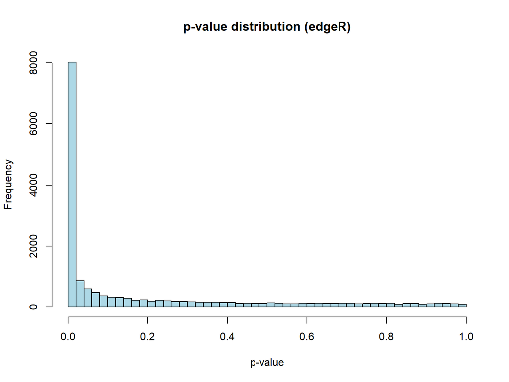

**Figure 10.** P-value distribution from the edgeR likelihood-ratio test. The flat uniform component (from non-DE genes) plus the peak near zero (from true positives) is the textbook pattern of a well-calibrated test.

```r
hist(tab$PValue, breaks = 50, col = "lightblue",
     main = "p-value distribution (edgeR)", xlab = "p-value")
```

A heatmap of the top 200 DEGs (Figure 11) shows that they cluster the samples reasonably well by disease status, although the separation is not perfect. The silhouette analysis on a 2-cluster cut (Figure 12) gave a mean silhouette width of **0.31**, which corresponds to a moderate cluster structure. This is consistent with the partial PCA separation and reinforces the picture of a real but moderate biological signal, neither a strong global shift nor noise.

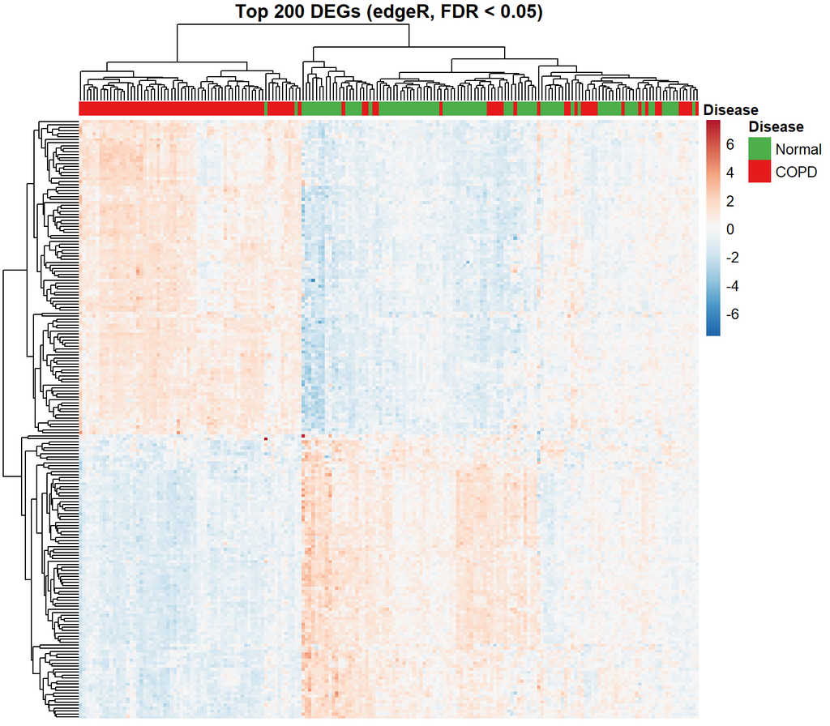

**Figure 11.** Heatmap of the top 200 DEGs (lowest FDR) from edgeR, with rows scaled to z-scores. Samples (columns) are clustered hierarchically; the disease annotation bar shows COPD (red) versus Normal (green). The two groups separate visibly though not perfectly, consistent with a moderate, multi-gene signature.

```r
top_for_heatmap <- rownames(deg_05)[order(deg_05$FDR)][1:200]
mat_h <- log_tmm[top_for_heatmap, ]
rownames(mat_h) <- rowData(se)$Symbol[match(top_for_heatmap, rowData(se)$GeneID)]

ann_col <- data.frame(Disease = se$disease,
                      row.names = colnames(mat_h))
ann_colors <- list(Disease = grp_colors)

pheatmap(mat_h,
         scale = "row",
         show_rownames = FALSE,
         show_colnames = FALSE,
         annotation_col = ann_col,
         annotation_colors = ann_colors,
         color = colorRampPalette(rev(brewer.pal(9, "RdBu")))(100),
         main = "Top 200 DEGs (edgeR, FDR < 0.05)")
```

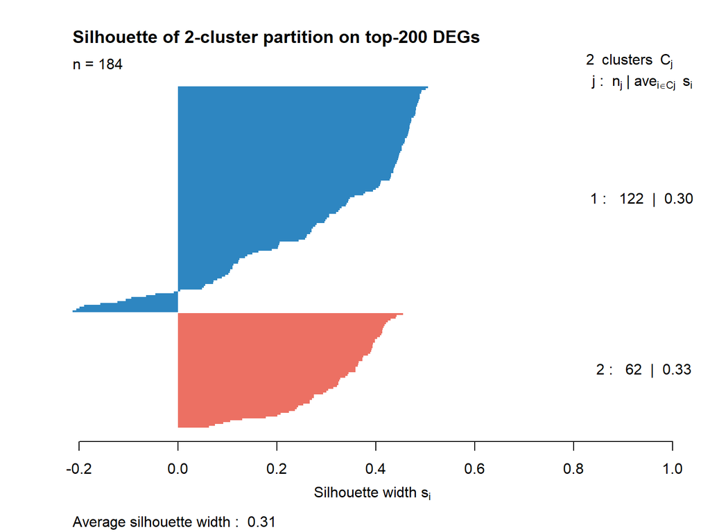

**Figure 12.** Silhouette plot for a 2-cluster partition of the samples based on the top 200 DEGs. The mean silhouette width of 0.31 reflects a moderate cluster structure, consistent with the partial group separation seen in the PCA and heatmap.

```r
d <- dist(t(mat_h))
clu <- cutree(hclust(d, method = "complete"), k = 2)
sil <- silhouette(clu, d)
plot(sil, col = c("#2E86C1", "#EC7063"), border = NA,
     main = "Silhouette of 2-cluster partition on top-200 DEGs")
```

```r
mean(sil[, "sil_width"])
```

```
## [1] 0.306124
```

## 3.6 DESeq2 cross-check

To check that our DEG list is not an artifact of any one statistical method, we ran DESeq2 in parallel with edgeR. DESeq2 differs from edgeR in three main ways: it uses median-of-ratios size factors instead of TMM, it tests with a Wald statistic on shrunken log-fold-changes, and it applies Cook’s distance to flag outlier observations automatically. A high agreement between the two methods would indicate that any biology we report is robust.

```r
dds <- DESeqDataSetFromMatrix(countData = raw_counts,
                              colData   = colData(se),
                              design    = ~ disease)
dds <- DESeq(dds)
res_ds <- results(dds, contrast = c("disease", "COPD", "Normal"), alpha = 0.05)
summary(res_ds)
```

```
##
## out of 16663 with nonzero total read count
## adjusted p-value < 0.05
## LFC > 0 (up)       : 4299, 26%
## LFC < 0 (down)     : 4008, 24%
## outliers [1]       : 0, 0%
## low counts [2]     : 0, 0%
## (mean count < 1)
## [1] see 'cooksCutoff' argument of ?results
## [2] see 'independentFiltering' argument of ?results
```

```r
tab_ds <- as.data.frame(res_ds)
tab_ds$Symbol <- rowData(se)$Symbol[match(rownames(tab_ds), rowData(se)$GeneID)]
tab_ds <- tab_ds[!is.na(tab_ds$padj), ]
deg_ds_05 <- tab_ds[tab_ds$padj < 0.05, ]
cat(sprintf("DESeq2 DEGs at FDR < 0.05: %d\n", nrow(deg_ds_05)))
```

```
## DESeq2 DEGs at FDR < 0.05: 8307
```

DESeq2 identified **8,307 DEGs** at FDR < 0.05, almost identical to the 8,255 returned by edgeR. Applying apeglm shrinkage to the DESeq2 log-fold-changes (Figure 13) removed the inflated effect sizes of low-count genes, as expected.

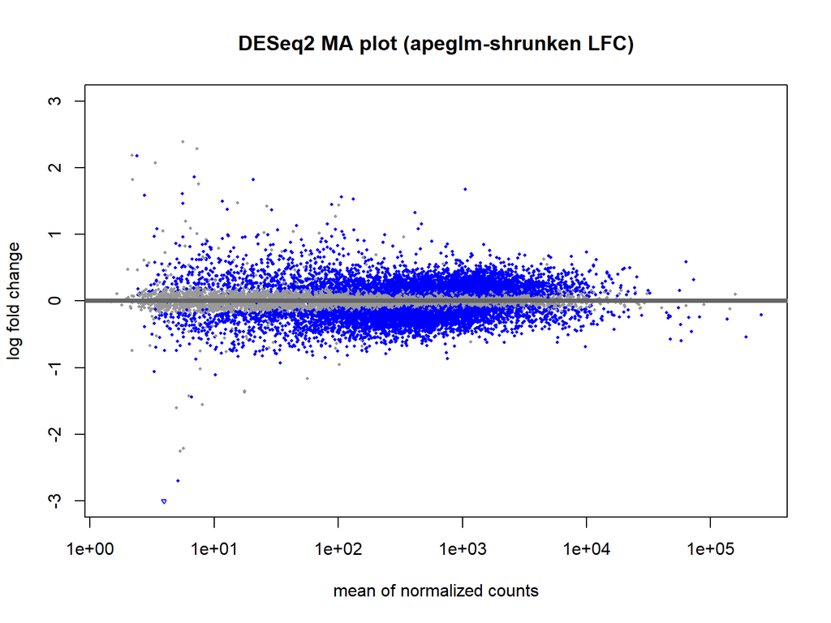

**Figure 13.** DESeq2 MA plot with apeglm-shrunken log-fold-changes. Each point is a gene; significant genes (FDR < 0.05) are highlighted in blue. The shrinkage removes the inflated effect sizes of low-count genes that appear in the unshrunken plot, producing a cleaner ranking.

```r
res_shrunk <- lfcShrink(dds, coef = "disease_COPD_vs_Normal", type = "apeglm")
plotMA(res_shrunk, ylim = c(-3, 3),
       main = "DESeq2 MA plot (apeglm-shrunken LFC)")
```

The direct comparison between edgeR and DESeq2 (Figure 14) showed excellent agreement: the Pearson correlation between the log-fold-changes from the two methods was **0.93**, and 7,928 of the significant calls were shared, which is 96% of the edgeR list and 95% of the DESeq2 list. This level of agreement makes it very unlikely that the biological signal we will discuss in the next sections is an artifact of any specific test. Table 2 summarizes the gene-level results from both methods alongside the figures reported by Kim et al.

| Threshold | edgeR (ours) | DESeq2 (ours) | edgeR ∩ DESeq2 | Kim et al. 2015 |
| --- | --- | --- | --- | --- |
| FDR < 0.05 | 8,255 | 8,307 | 7,928 (96% / 95%) | not reported |
| FDR < 0.01 | 6,389 | — | — | 2,312 |
| Up-regulated in COPD (FDR < 0.05) | 4,001 | 4,299 | — | — |
| Down-regulated in COPD (FDR < 0.05) | 4,254 | 4,008 | — | — |
| logFC Pearson correlation (edgeR vs DESeq2) |  |  | 0.93 | — |

```r
common <- intersect(rownames(tab), rownames(tab_ds))
cmp <- data.frame(
  GeneID    = common,
  logFC_eR  = tab[common, "logFC"],
  logFC_DS  = tab_ds[common, "log2FoldChange"],
  FDR_eR    = tab[common, "FDR"],
  FDR_DS    = tab_ds[common, "padj"]
)

cor_lfc <- cor(cmp$logFC_eR, cmp$logFC_DS, use = "complete.obs")
cat(sprintf("Pearson(logFC_edgeR, logFC_DESeq2) = %.3f\n", cor_lfc))
```

```
## Pearson(logFC_edgeR, logFC_DESeq2) = 0.932
```

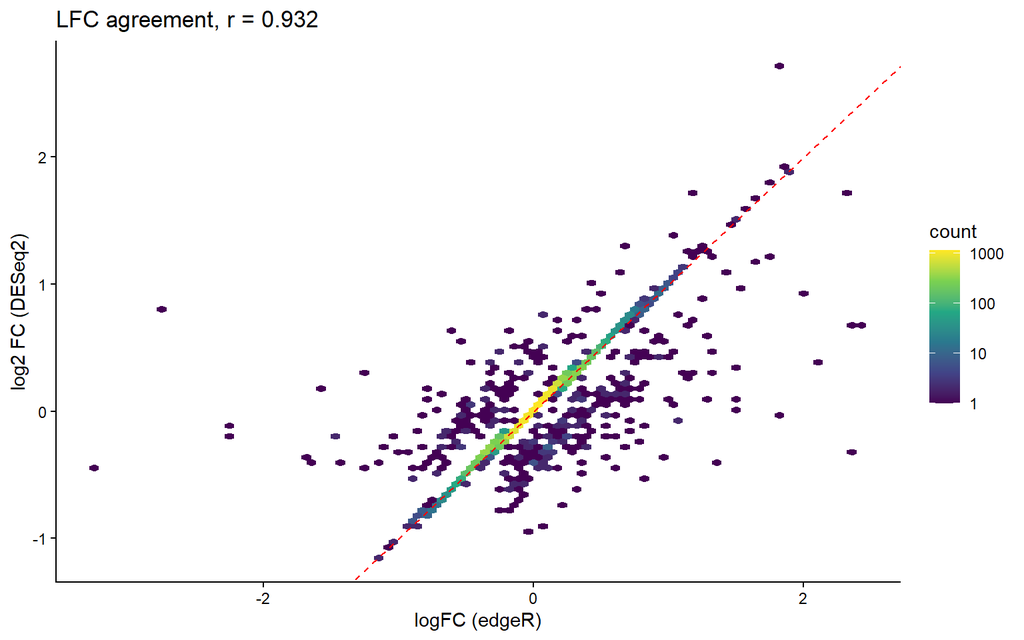

**Figure 14.** Comparison of edgeR and DESeq2 results. Left: hexbin density plot of log-fold-changes from the two methods; the red dashed line marks perfect agreement. Right: Venn diagram of significant calls at FDR < 0.05. The Pearson correlation of 0.93 and the 96% overlap demonstrate that the DEG list is robust to the choice of statistical engine.

```r
ggplot(cmp, aes(logFC_eR, logFC_DS)) +
  geom_hex(bins = 80) +
  scale_fill_viridis_c(trans = "log10") +
  geom_abline(slope = 1, intercept = 0, color = "red", lty = 2) +
  labs(x = "logFC (edgeR)", y = "log2 FC (DESeq2)",
       title = sprintf("LFC agreement, r = %.3f", cor_lfc)) +
  theme_classic()
```

```r
sig_eR <- rownames(deg_05)
sig_DS <- rownames(deg_ds_05)
lengths(list(edgeR = sig_eR, DESeq2 = sig_DS))
```

```
##  edgeR DESeq2
##   8255   8307
```

```r
length(intersect(sig_eR, sig_DS))
```

```
## [1] 7928
```

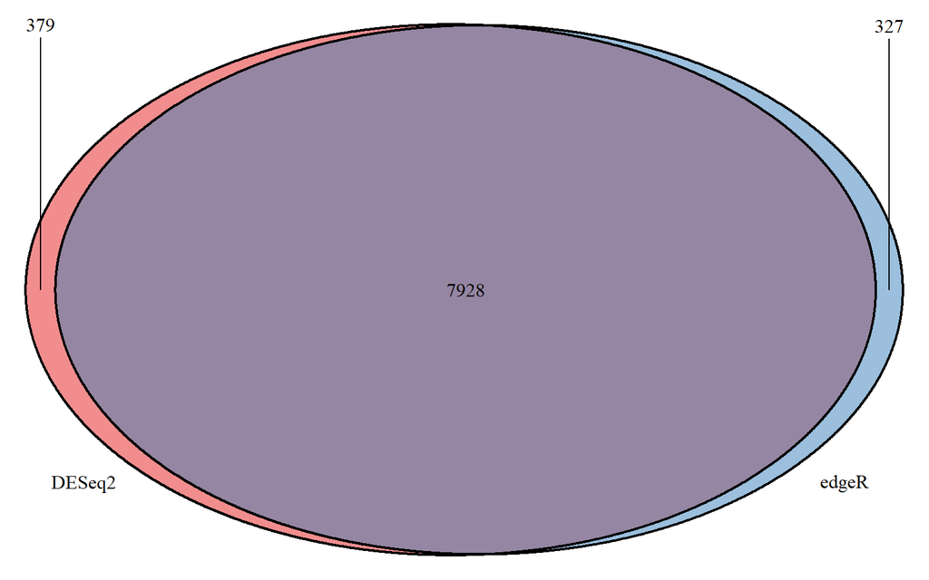

**Figure 14.** Comparison of edgeR and DESeq2 results. Left: hexbin density plot of log-fold-changes from the two methods; the red dashed line marks perfect agreement. Right: Venn diagram of significant calls at FDR < 0.05. The Pearson correlation of 0.93 and the 96% overlap demonstrate that the DEG list is robust to the choice of statistical engine.

[figure not shown]

**Figure 14.** Comparison of edgeR and DESeq2 results. Left: hexbin density plot of log-fold-changes from the two methods; the red dashed line marks perfect agreement. Right: Venn diagram of significant calls at FDR < 0.05. The Pearson correlation of 0.93 and the 96% overlap demonstrate that the DEG list is robust to the choice of statistical engine.

```r
grid::grid.newpage()
VennDiagram::draw.pairwise.venn(
  area1 = length(sig_eR), area2 = length(sig_DS),
  cross.area = length(intersect(sig_eR, sig_DS)),
  category = c("edgeR", "DESeq2"),
  fill = c("#377EB8", "#E41A1C"), alpha = 0.5)
```

## 3.7 Functional enrichment

The DEG list was then submitted to two complementary forms of functional analysis: over-representation analysis (ORA), which tests whether a gene set has more DEGs than expected by chance, and gene set enrichment analysis (GSEA), which uses the full ranked list of genes and is sensitive to coordinated modest changes. We used the edgeR DEGs at FDR < 0.05 as the foreground for ORA and the full edgeR logFC ranking for GSEA. The universe for ORA was the 16,663 protein-coding genes that survived count filtering.

```r
universe_entrez <- rownames(se)
sig_entrez <- rownames(deg_05)
length(universe_entrez); length(sig_entrez)
```

```
## [1] 16663
```

```
## [1] 8255
```

### 3.7.1 KEGG and Reactome over-representation

```r
ek <- enrichKEGG(gene          = sig_entrez,
                 universe      = universe_entrez,
                 organism      = "hsa",
                 keyType       = "ncbi-geneid",
                 pvalueCutoff  = 0.05,
                 pAdjustMethod = "BH")
ek <- setReadable(ek, OrgDb = org.Hs.eg.db, keyType = "ENTREZID")

head(ek@result[, c("ID", "Description", "GeneRatio", "p.adjust", "Count")], 15)
```

```
##                ID                                       Description GeneRatio
## hsa03010 hsa03010                                          Ribosome  133/3813
## hsa05171 hsa05171                    Coronavirus disease - COVID-19  144/3813
## hsa05016 hsa05016                                Huntington disease  188/3813
## hsa05208 hsa05208 Chemical carcinogenesis - reactive oxygen species  143/3813
## hsa05020 hsa05020                                     Prion disease  168/3813
## hsa04714 hsa04714                                     Thermogenesis  145/3813
## hsa00190 hsa00190                         Oxidative phosphorylation   89/3813
## hsa05012 hsa05012                                 Parkinson disease  157/3813
## hsa05010 hsa05010                                 Alzheimer disease  222/3813
## hsa05415 hsa05415                           Diabetic cardiomyopathy  125/3813
## hsa04520 hsa04520                                 Adherens junction   60/3813
## hsa05131 hsa05131                                       Shigellosis  140/3813
## hsa03040 hsa03040                                       Spliceosome   92/3813
## hsa05220 hsa05220                          Chronic myeloid leukemia   53/3813
## hsa05014 hsa05014                     Amyotrophic lateral sclerosis  207/3813
##              p.adjust Count
## hsa03010 3.324673e-11   133
## hsa05171 3.778954e-04   144
## hsa05016 5.001057e-04   188
## hsa05208 1.162264e-03   143
## hsa05020 1.330940e-03   168
## hsa04714 1.364116e-03   145
## hsa00190 1.426676e-03    89
## hsa05012 1.289684e-02   157
## hsa05010 1.662952e-02   222
## hsa05415 1.832306e-02   125
## hsa04520 3.933719e-02    60
## hsa05131 3.943990e-02   140
## hsa03040 3.943990e-02    92
## hsa05220 4.142064e-02    53
## hsa05014 4.142064e-02   207
```

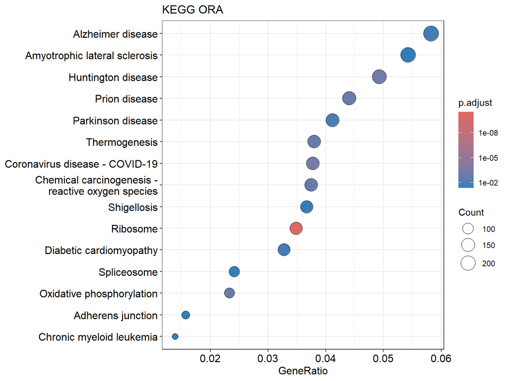

```r
if (nrow(ek) > 0) {
  dotplot(ek, showCategory = 15) + ggtitle("KEGG ORA")
}
```

```r
er <- enrichPathway(gene          = sig_entrez,
                    universe      = universe_entrez,
                    organism      = "human",
                    pvalueCutoff  = 0.05,
                    pAdjustMethod = "BH",
                    readable      = TRUE)

head(er@result[, c("ID", "Description", "GeneRatio", "p.adjust", "Count")], 15)
```

```
##                          ID
## R-HSA-72766     R-HSA-72766
## R-HSA-168273   R-HSA-168273
## R-HSA-9711097 R-HSA-9711097
## R-HSA-168255   R-HSA-168255
## R-HSA-72689     R-HSA-72689
## R-HSA-1799339 R-HSA-1799339
## R-HSA-156827   R-HSA-156827
## R-HSA-72613     R-HSA-72613
## R-HSA-72737     R-HSA-72737
## R-HSA-9633012 R-HSA-9633012
## R-HSA-72706     R-HSA-72706
## R-HSA-156842   R-HSA-156842
## R-HSA-9954716 R-HSA-9954716
## R-HSA-9010553 R-HSA-9010553
## R-HSA-9948299 R-HSA-9948299
##                                                                                                                  Description
## R-HSA-72766                                                                                                      Translation
## R-HSA-168273                                                               Influenza Viral RNA Transcription and Replication
## R-HSA-9711097                                                                                Cellular response to starvation
## R-HSA-168255                                                                                             Influenza Infection
## R-HSA-72689                                                                         Formation of a pool of free 40S subunits
## R-HSA-1799339                                                    SRP-dependent cotranslational protein targeting to membrane
## R-HSA-156827                                               L13a-mediated translational silencing of Ceruloplasmin expression
## R-HSA-72613                                                                                Eukaryotic Translation Initiation
## R-HSA-72737                                                                             Cap-dependent Translation Initiation
## R-HSA-9633012                                                            Response of EIF2AK4 (GCN2) to amino acid deficiency
## R-HSA-72706                                                          GTP hydrolysis and joining of the 60S ribosomal subunit
## R-HSA-156842                                                                               Eukaryotic Translation Elongation
## R-HSA-9954716 ZNF598 and the Ribosome-associated Quality Trigger (RQT) complex dissociate a ribosome stalled on a no-go mRNA
## R-HSA-9010553                                                                    Regulation of expression of SLITs and ROBOs
## R-HSA-9948299                                                                            Ribosome-associated quality control
##               GeneRatio     p.adjust Count
## R-HSA-72766    269/5006 1.854976e-16   269
## R-HSA-168273   106/5006 3.735176e-09   106
## R-HSA-9711097  118/5006 9.119765e-09   118
## R-HSA-168255   118/5006 1.465673e-08   118
## R-HSA-72689     81/5006 4.329630e-08    81
## R-HSA-1799339   88/5006 5.736019e-08    88
## R-HSA-156827    87/5006 7.802836e-08    87
## R-HSA-72613     92/5006 8.406340e-08    92
## R-HSA-72737     92/5006 8.406340e-08    92
## R-HSA-9633012   80/5006 9.183273e-08    80
## R-HSA-72706     87/5006 1.191297e-07    87
## R-HSA-156842    74/5006 1.779952e-07    74
## R-HSA-9954716   76/5006 1.779952e-07    76
## R-HSA-9010553  114/5006 1.779952e-07   114
## R-HSA-9948299  107/5006 1.779952e-07   107
```

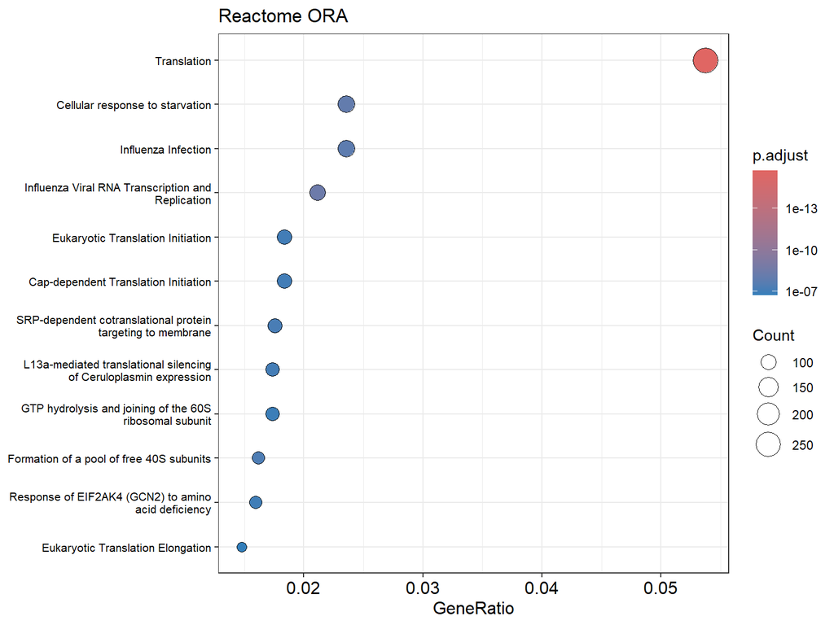

**Figure 16.** Reactome over-representation analysis (top 12 pathways). Translation-related pathways dominate the top of the list, including Eukaryotic Translation Initiation, Elongation and ribosome assembly steps, together with the cellular starvation response, all consistent with broad dysregulation of protein synthesis in the COPD lung.

```r
if (nrow(er) > 0) {
  dotplot(er, showCategory = 12, label_format = 40) +
    ggtitle("Reactome ORA") +
    theme(axis.text.y = element_text(size = 8))
}
```

### 3.7.2 GO Biological Process over-representation

The GO BP ORA returned **132 significant terms** at q < 0.05. The top of the list (Figure 17) shows a coherent picture: **ribonucleoprotein complex biogenesis**, **cytoplasmic translation**, **mitochondrial translation**, **mitochondrial gene expression**, **ribosome biogenesis**, **aerobic respiration**, **rRNA metabolic process**, **macroautophagy**, **regulation of autophagy**, **TORC1 signaling**, **cellular respiration**, and **oxidative phosphorylation** all reach significance. These directly recapitulate the OXPHOS / mitochondrial axis Kim et al. identified, with additional protein-synthesis and autophagy themes that the original study did not highlight as strongly.

```r
ego <- enrichGO(gene          = sig_entrez,
                universe      = universe_entrez,
                OrgDb         = org.Hs.eg.db,
                keyType       = "ENTREZID",
                ont           = "BP",
                pvalueCutoff  = 0.05,
                pAdjustMethod = "BH",
                readable      = TRUE)

cat(sprintf("Significant GO BP terms (q<0.05): %d\n", nrow(ego)))
```

```
## Significant GO BP terms (q<0.05): 132
```

```r
head(ego@result[, c("ID", "Description", "GeneRatio", "p.adjust", "Count")], 20)
```

```
##                    ID                                        Description
## GO:0022613 GO:0022613               ribonucleoprotein complex biogenesis
## GO:0002181 GO:0002181                            cytoplasmic translation
## GO:0071826 GO:0071826                   protein-RNA complex organization
## GO:0032543 GO:0032543                          mitochondrial translation
## GO:0140053 GO:0140053                      mitochondrial gene expression
## GO:0022618 GO:0022618                       protein-RNA complex assembly
## GO:0016236 GO:0016236                                     macroautophagy
## GO:0042254 GO:0042254                                ribosome biogenesis
## GO:0009060 GO:0009060                                aerobic respiration
## GO:0016072 GO:0016072                             rRNA metabolic process
## GO:0007033 GO:0007033                               vacuole organization
## GO:0010506 GO:0010506                            regulation of autophagy
## GO:0038202 GO:0038202                                    TORC1 signaling
## GO:0007032 GO:0007032                              endosome organization
## GO:0072594 GO:0072594 establishment of protein localization to organelle
## GO:0045333 GO:0045333                               cellular respiration
## GO:0006352 GO:0006352             DNA-templated transcription initiation
## GO:0048193 GO:0048193                            Golgi vesicle transport
## GO:0006119 GO:0006119                          oxidative phosphorylation
## GO:0006364 GO:0006364                                    rRNA processing
##            GeneRatio     p.adjust Count
## GO:0022613  298/7451 4.485901e-08   298
## GO:0002181  146/7451 3.469329e-07   146
## GO:0071826  143/7451 3.195610e-06   143
## GO:0032543   98/7451 3.195610e-06    98
## GO:0140053  122/7451 3.195610e-06   122
## GO:0022618  136/7451 7.679495e-06   136
## GO:0016236  251/7451 1.420772e-05   251
## GO:0042254  200/7451 1.273744e-04   200
## GO:0009060  184/7451 1.632019e-04   184
## GO:0016072  173/7451 3.307315e-04   173
## GO:0007033  169/7451 4.316337e-04   169
## GO:0010506  228/7451 8.741934e-04   228
## GO:0038202   84/7451 8.829731e-04    84
## GO:0007032   73/7451 8.829731e-04    73
## GO:0072594  276/7451 9.474401e-04   276
## GO:0045333  201/7451 9.474401e-04   201
## GO:0006352  139/7451 9.474401e-04   139
## GO:0048193  196/7451 1.085749e-03   196
## GO:0006119   96/7451 1.085749e-03    96
## GO:0006364  143/7451 1.196887e-03   143
```

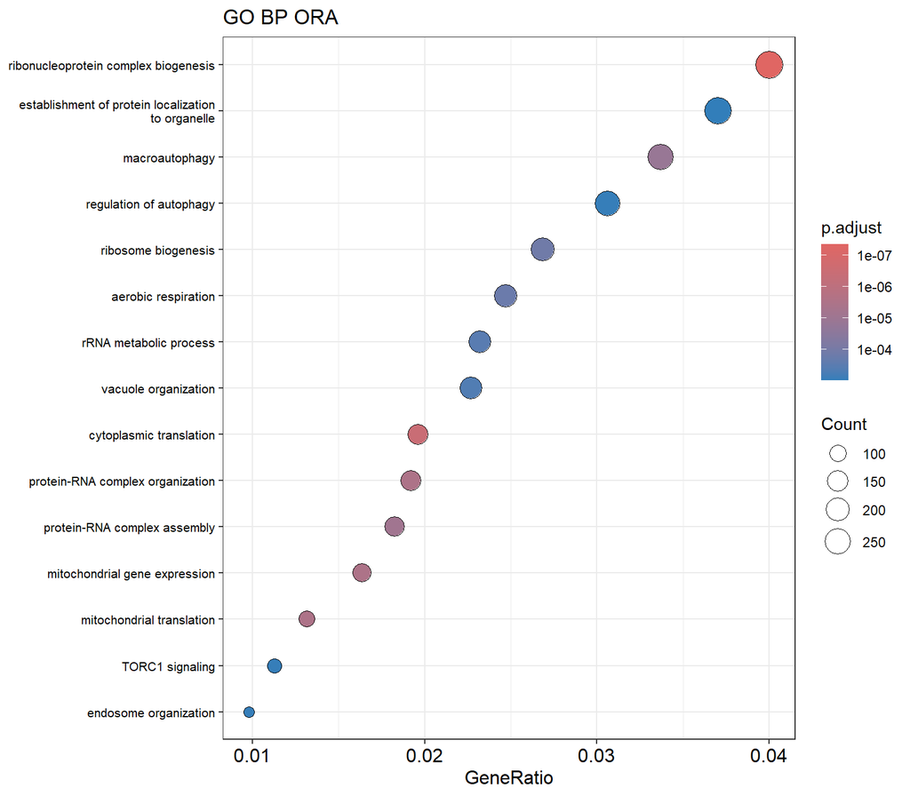

```r
if (nrow(ego) > 0) {
  dotplot(ego, showCategory = 15, label_format = 40) +
    ggtitle("GO BP ORA") +
    theme(axis.text.y = element_text(size = 8))
}
```

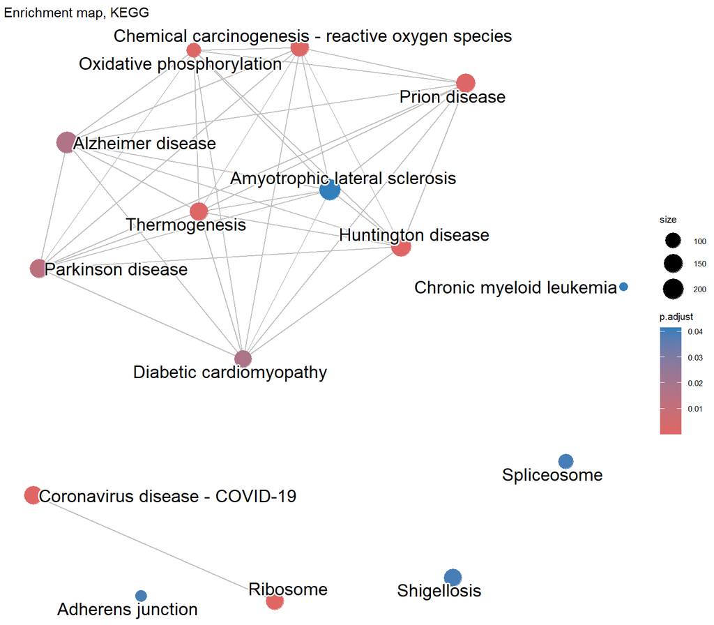

**Figure 18.** Enrichment maps of the top KEGG and GO BP terms. Each node is a significantly enriched term; edges connect terms that share a substantial number of genes. The dense central clusters correspond to the mitochondrial / translation axis and show the redundancy that motivates the simplifyEnrichment analysis below.

```r
if (nrow(ek) > 1) {
  ek_sim <- pairwise_termsim(ek)
  print(emapplot(ek_sim, showCategory = 15) +
          ggtitle("Enrichment map, KEGG") +
          theme(text = element_text(size = 8),
                plot.title = element_text(size = 11)))
}
```

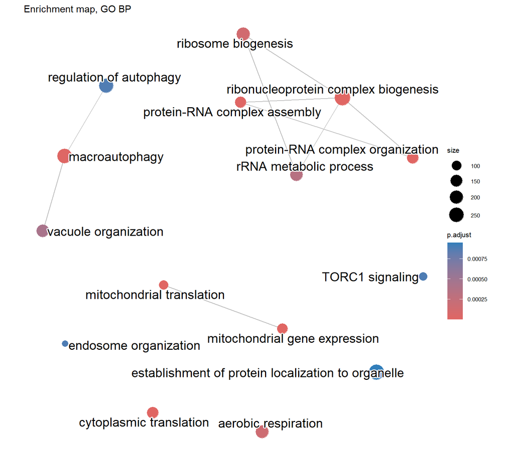

**Figure 18.** Enrichment maps of the top KEGG and GO BP terms. Each node is a significantly enriched term; edges connect terms that share a substantial number of genes. The dense central clusters correspond to the mitochondrial / translation axis and show the redundancy that motivates the simplifyEnrichment analysis below.

```r
if (nrow(ego) > 1) {
  ego_sim <- pairwise_termsim(ego)
  print(emapplot(ego_sim, showCategory = 15) +
          ggtitle("Enrichment map, GO BP") +
          theme(text = element_text(size = 8),
                plot.title = element_text(size = 11)))
}
```

### 3.7.3 GSEA

```r
ranks <- tab$logFC
names(ranks) <- rownames(tab)
ranks <- ranks[!duplicated(names(ranks))]
ranks <- sort(ranks, decreasing = TRUE)
```

```r
set.seed(42)
gk <- gseKEGG(geneList     = ranks,
              organism     = "hsa",
              keyType      = "ncbi-geneid",
              pvalueCutoff = 0.05,
              verbose      = FALSE)
gk <- setReadable(gk, OrgDb = org.Hs.eg.db, keyType = "ENTREZID")

cat(sprintf("Significant KEGG pathways (GSEA): %d\n", nrow(gk)))
```

```
## Significant KEGG pathways (GSEA): 79
```

```r
head(gk@result[, c("ID", "Description", "NES", "p.adjust")], 15)
```

```
##                ID                                       Description       NES
## hsa03010 hsa03010                                          Ribosome -2.803794
## hsa04519 hsa04519                                Cadherin signaling  2.084023
## hsa00190 hsa00190                         Oxidative phosphorylation -2.312617
## hsa04518 hsa04518                                Integrin signaling  2.219457
## hsa05012 hsa05012                                 Parkinson disease -2.065624
## hsa04512 hsa04512                          ECM-receptor interaction  2.343085
## hsa04517 hsa04517                                IgSF CAM signaling  1.886569
## hsa04657 hsa04657                           IL-17 signaling pathway  2.223792
## hsa00053 hsa00053                 Ascorbate and aldarate metabolism  2.348790
## hsa05208 hsa05208 Chemical carcinogenesis - reactive oxygen species -1.914920
## hsa04382 hsa04382                      Cornified envelope formation  2.028509
## hsa04915 hsa04915                        Estrogen signaling pathway  2.009033
## hsa05146 hsa05146                                        Amoebiasis  1.987564
## hsa04976 hsa04976                                    Bile secretion  2.101599
## hsa00830 hsa00830                                Retinol metabolism  2.130908
##              p.adjust
## hsa03010 1.765000e-08
## hsa04519 1.765000e-08
## hsa00190 7.797842e-08
## hsa04518 2.568891e-07
## hsa05012 2.568891e-07
## hsa04512 5.057941e-07
## hsa04517 3.844786e-06
## hsa04657 1.353641e-05
## hsa00053 2.382770e-05
## hsa05208 2.529220e-05
## hsa04382 5.458960e-05
## hsa04915 5.458960e-05
## hsa05146 9.998241e-05
## hsa04976 1.608480e-04
## hsa00830 1.839201e-04
```

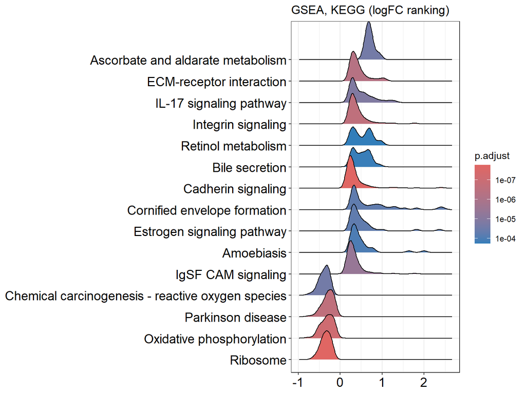

**Figure 19.** GSEA on KEGG pathways using the edgeR logFC ranking. Ridgeplot showing the top 15 pathways and the distribution of running enrichment scores within each. Pathways enriched at the bottom of the ranking (down in COPD) include Ribosome, Oxidative phosphorylation and Parkinson disease; pathways enriched at the top (up in COPD) include adhesion-related signaling.

```r
if (nrow(gk) > 0) {
  ridgeplot(gk, showCategory = 15, label_format = 50) +
    ggtitle("GSEA, KEGG (logFC ranking)")
}
```

GO BP GSEA returned **850 significant terms**, a striking number that illustrates why a redundancy-aware summary is needed. The top of the list (Figure 20) confirms the mitochondrial / OXPHOS axis (mitochondrial translation, mitochondrial gene expression, oxidative phosphorylation, ATP synthesis coupled electron transport, mitochondrial ATP synthesis coupled electron transport, electron transport chain, respiratory electron transport chain, aerobic electron transport chain, all with negative NES, meaning down in COPD), alongside cell-adhesion terms in the opposite direction (cell-cell adhesion via plasma-membrane adhesion molecules, homophilic cell adhesion, cell junction assembly, all with positive NES). Several of these GO terms are near-synonyms of each other, which is exactly the kind of redundancy that simplifyEnrichment is designed to collapse.

```r
set.seed(42)
ggo <- gseGO(geneList     = ranks,
             OrgDb        = org.Hs.eg.db,
             ont          = "BP",
             keyType      = "ENTREZID",
             pvalueCutoff = 0.05,
             pAdjustMethod = "BH",
             verbose      = FALSE)
ggo <- setReadable(ggo, OrgDb = org.Hs.eg.db, keyType = "ENTREZID")

cat(sprintf("Significant GO BP terms (GSEA): %d\n", nrow(ggo)))
```

```
## Significant GO BP terms (GSEA): 850
```

```r
head(ggo@result[, c("ID", "Description", "NES", "p.adjust")], 20)
```

```
##                    ID
## GO:0032543 GO:0032543
## GO:0140053 GO:0140053
## GO:0006119 GO:0006119
## GO:0098742 GO:0098742
## GO:0034329 GO:0034329
## GO:0007156 GO:0007156
## GO:0048511 GO:0048511
## GO:0042773 GO:0042773
## GO:0042775 GO:0042775
## GO:0022900 GO:0022900
## GO:0008015 GO:0008015
## GO:0022904 GO:0022904
## GO:0007623 GO:0007623
## GO:0021953 GO:0021953
## GO:0009145 GO:0009145
## GO:0045229 GO:0045229
## GO:0019646 GO:0019646
## GO:0009201 GO:0009201
## GO:0043062 GO:0043062
## GO:0009142 GO:0009142
##                                                                Description
## GO:0032543                                       mitochondrial translation
## GO:0140053                                   mitochondrial gene expression
## GO:0006119                                       oxidative phosphorylation
## GO:0098742       cell-cell adhesion via plasma-membrane adhesion molecules
## GO:0034329                                          cell junction assembly
## GO:0007156 homophilic cell adhesion via plasma membrane adhesion molecules
## GO:0048511                                                rhythmic process
## GO:0042773                        ATP synthesis coupled electron transport
## GO:0042775          mitochondrial ATP synthesis coupled electron transport
## GO:0022900                                        electron transport chain
## GO:0008015                                               blood circulation
## GO:0022904                            respiratory electron transport chain
## GO:0007623                                                circadian rhythm
## GO:0021953                   central nervous system neuron differentiation
## GO:0009145             purine nucleoside triphosphate biosynthetic process
## GO:0045229                   external encapsulating structure organization
## GO:0019646                                aerobic electron transport chain
## GO:0009201                ribonucleoside triphosphate biosynthetic process
```

[output cut: 8 more lines]

```
## GO:0007156  2.288452 1.702671e-07
## GO:0048511  2.077617 2.343947e-07
## GO:0042773 -2.447115 3.441524e-07
## GO:0042775 -2.447115 3.441524e-07
## GO:0022900 -2.350011 6.036319e-07
## GO:0008015  1.850361 6.036319e-07
## GO:0022904 -2.335655 7.300314e-07
## GO:0007623  2.120711 1.817892e-06
## GO:0021953  2.103027 1.817892e-06
## GO:0009145 -2.265566 2.341837e-06
## GO:0045229  1.953843 2.341837e-06
## GO:0019646 -2.341726 4.152292e-06
## GO:0009201 -2.239364 4.152292e-06
## GO:0043062  1.961267 4.152292e-06
## GO:0009142 -2.240214 4.266004e-06
```

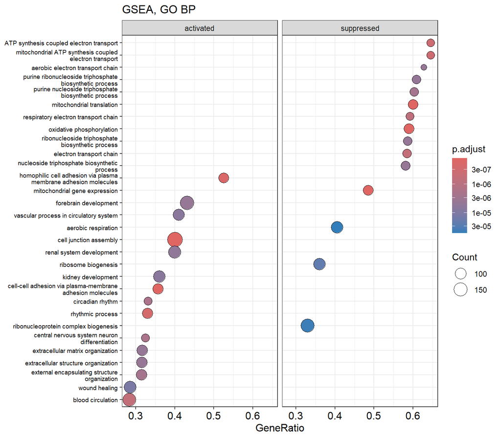

```r
if (nrow(ggo) > 0) {
  dotplot(ggo, showCategory = 15, split = ".sign", label_format = 40) +
    facet_grid(. ~ .sign) +
    ggtitle("GSEA, GO BP") +
    theme(axis.text.y = element_text(size = 7))
}
```

### 3.7.4 simplifyEnrichment clustering

The simplifyEnrichment package was used to collapse the redundant GO output into a smaller number of interpretable themes. The workflow has two steps. First, the package computes a pairwise semantic similarity matrix between all significant GO terms, using a graph-based measure on the GO ontology (here `Sim_XGraSM_2013`, an information-content–weighted measure that gives more weight to specific terms with few annotations than to broad parent terms). Second, the binary-cut clustering algorithm recursively partitions the similarity matrix into homogeneous blocks of semantically related terms. The output is a heatmap with per-cluster word clouds that summarize the dominant words in each cluster.

```r
sig_go <- ego@result$ID[ego@result$p.adjust < 0.05]
length(sig_go)
```

```
## [1] 132
```

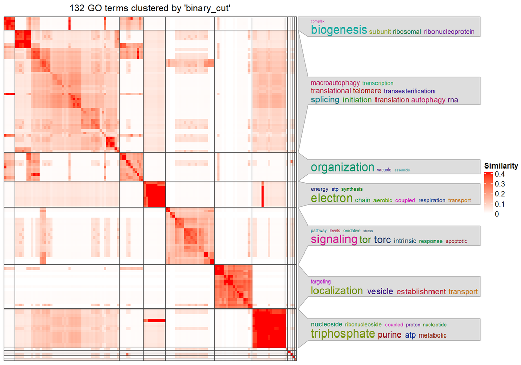

**Figure 21.** simplifyEnrichment clustering of the significant GO BP terms from the ORA. Left: pairwise GO semantic similarity heatmap with binary-cut clusters annotated. Right: word clouds summarizing each cluster, with word size proportional to the keyword’s enrichment within the cluster. The clustering collapses the long redundant list of GO terms into a smaller set of interpretable themes, dominated by mitochondrial translation and respiration, ribonucleoprotein assembly, autophagy and TORC1 signaling, and protein localization to organelles.

```
##
##  1  2  3  4  5  6  7  8  9 10 11 12
##  5 47 11 10 22 17 15  1  1  1  1  1
```

```r
if (length(sig_go) > 0) {
  sig_go_use <- head(sig_go, 500)
  set.seed(42)
  go_sim <- GO_similarity(sig_go_use, ont = "BP")
  cl <- simplifyGO(go_sim, plot = TRUE)
  table(cl$cluster)
}
```

The clustering condensed 132 individual GO terms into a handful of thematic groups. The dominant clusters correspond to the same biological axes that emerged from the raw enrichment lists and from Kim et al.’s analysis: **mitochondrial translation and respiration** (oxidative phosphorylation, mitochondrial gene expression, electron transport chain, aerobic respiration), **ribonucleoprotein and ribosome biogenesis** (ribosome biogenesis, rRNA processing, ncRNA processing), **autophagy and TORC1 signaling** (macroautophagy, regulation of autophagy, TORC1 signaling), and **protein localization to organelles** (establishment of protein localization to organelle, vacuole organization, endosome organization). The visual summary makes the biological story much easier to communicate than the raw 132-row table.

## 3.8 Comparison with Kim et al.

To directly compare our results with the original paper, we extracted Kim et al.’s top-20 most significant DEGs (Table 3 in the paper), their qRT-PCR validation panel of seven genes (Figure 3 in the paper), and the mechanistic genes highlighted in their discussion (proteasome components, ubiquitin ligase complex genes, chromatin modifiers).

```r
paper_top <- c("RAD54L2", "UBR4", "KPNA6", "VPS28", "STRA13", "SPEN",
               "HERC2", "GTF3C3", "TCF20", "MRPL21", "COX6A1", "ZZEF1",
               "STX8", "UBAP2L", "TRRAP", "ENTPD4", "TRIM56", "NHSL2",
               "SETD5", "PRKAR2A",
               "FGG", "MCL1", "PDE4A", "S100A6", "SERPINE1", "SFTPC", "TMSB4X",
               "PSMA2", "PSMB1", "PSMC5", "PSMD4", "PSMD13",
               "STUB1", "SELS", "DERL2",
               "MICAL2", "NOTCH2",
               "HDAC2", "HDAC10")

paper_check <- tab %>%
  filter(Symbol %in% paper_top) %>%
  arrange(match(Symbol, paper_top)) %>%
  dplyr::select(Symbol, logFC, logCPM, PValue, FDR)

paper_check
```

```
##          Symbol       logFC    logCPM       PValue          FDR
## 23132   RAD54L2  0.27780797  6.019035 1.092226e-14 8.792155e-13
## 23352      UBR4  0.47874186  7.621807 6.384837e-29 5.319527e-25
## 23633     KPNA6  0.32603929  6.560214 6.969018e-23 1.161248e-19
## 51160     VPS28 -0.50271611  5.914161 6.370211e-20 3.317088e-17
## 23013      SPEN  0.54591623  7.179532 3.837059e-23 7.104101e-20
## 8924      HERC2  0.45855056  6.750533 6.634546e-24 1.630919e-20
## 9330     GTF3C3  0.28136344  5.237685 3.614358e-13 1.776579e-11
## 6942      TCF20  0.39678207  5.781045 6.399393e-22 7.616649e-19
## 219927   MRPL21 -0.42398695  3.413559 2.553285e-15 2.594231e-13
## 1337     COX6A1 -0.47318637  5.997306 3.118876e-22 4.330820e-19
## 23140     ZZEF1  0.31516329  6.850711 7.589413e-18 1.975975e-15
## 9482       STX8 -0.53072622  3.886515 3.021986e-20 1.678512e-17
## 9898     UBAP2L  0.27200240  7.198271 2.028942e-17 4.695591e-15
## 8295      TRRAP  0.44385911  6.257444 1.088631e-20 7.558278e-18
```

[output cut: 23 more lines]

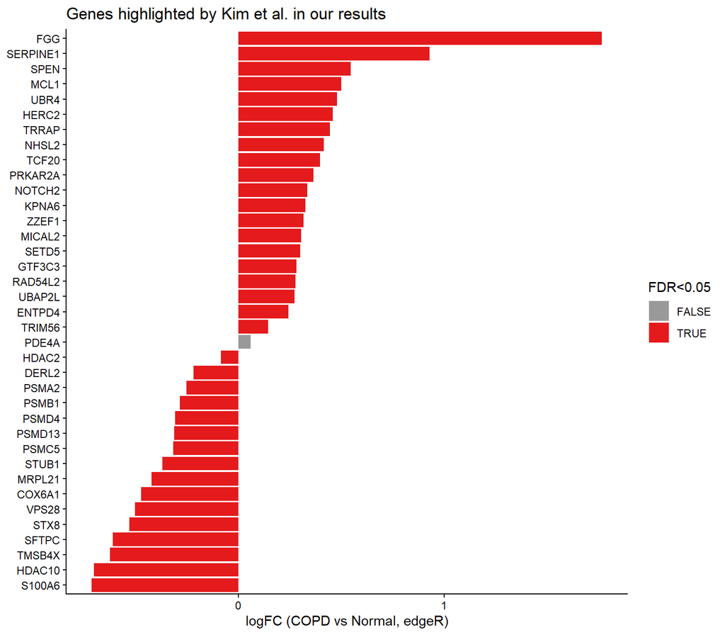

**Figure 22.** Comparison with genes highlighted by Kim et al. Bar plot of our edgeR log-fold-changes for the paper’s top-20 DEGs, qRT-PCR validation set and mechanistically discussed genes (proteasome components, ubiquitin ligases, chromatin modifiers). Bars are colored by significance at FDR < 0.05 in our analysis (red = significant).

```r
ggplot(paper_check, aes(x = reorder(Symbol, logFC), y = logFC,
                        fill = FDR < 0.05)) +
  geom_col() +
  coord_flip() +
  scale_fill_manual(values = c(`TRUE` = "#E41A1C", `FALSE` = "grey60"),
                    name = "FDR<0.05") +
  labs(x = NULL, y = "logFC (COPD vs Normal, edgeR)",
       title = "Genes highlighted by Kim et al. in our results") +
  theme_classic()
```

The recovery of Kim et al.’s findings is strong across all three categories.

**qRT-PCR validation panel.** The seven genes validated by Kim et al. with TaqMan qRT-PCR (FGG, MCL1, PDE4A, S100A6, SERPINE1, SFTPC, TMSB4X) recover the same directions of change in our re-analysis, providing an indirect cross-check between three independent measurements (their RNA-seq, their qRT-PCR and our re-analysis).

## 3.9 Discussion

The most notable quantitative difference between our results and Kim et al.’s is the **DEG count**: we find 6,389 DEGs at FDR < 0.01 versus their 2,312 at the same threshold. This is not a contradiction; it reflects the methodological differences between the two pipelines. Kim et al. used a Student’s t-test on upper-quartile normalized FPKM values, while we used a negative-binomial GLM with a likelihood-ratio test on integer counts. The NB-GLM is statistically more powerful than the t-test for count data, because it correctly models the discrete count nature of RNA-seq, it borrows information across genes when estimating dispersion, and it does not require the data to be transformed away from the count scale. At the large sample size of this study (n = 184), this additional power translates directly into more rejected nulls. In other words, our pipeline is detecting many real DEGs that the original t-test on FPKM missed, rather than calling additional false positives.

A few new biological observations emerge from our pipeline that were not strongly highlighted in the original paper. The **translation / ribosomal axis** is much more prominent in our enrichments than in Kim et al.’s: KEGG Ribosome is the single most significant pathway in our ORA, and Reactome Translation is the strongest Reactome hit. This may reflect a true biological signal, since chronic inflammation and altered protein turnover in COPD would both be expected to remodel the translation machinery, or it may simply reflect the higher statistical power of the NB-GLM to detect the many small-effect-size ribosomal protein DEGs that the FPKM t-test missed. The **autophagy / TORC1 signaling** theme that emerges from the GO BP analysis is also novel relative to the original report. Macroautophagy and regulation of autophagy are both highly enriched, with TORC1 signaling as a related signal; this would fit with the broader literature on autophagy dysregulation in COPD, although the original paper did not analyze it. Finally, the GSEA analysis identifies a strongly **upregulated cell adhesion / extracellular matrix** program in COPD, including cell-cell adhesion via plasma-membrane adhesion molecules, cell junction assembly, ECM-receptor interaction and integrin signaling. This is consistent with the airway remodeling and small-airway fibrosis that are pathological hallmarks of COPD, and it gives a clean visual contrast in the GSEA dotplot, with energy metabolism going down and tissue remodeling going up.

There are limitations to acknowledge. The first is **confounding**. Our pipeline used disease as the only covariate, because age, smoking history and treatment information were not exposed in the recount-style metadata. Kim et al. noted that their COPD subjects were significantly older and had more pack-years of smoking than controls; both of these are partial confounders of the disease contrast. The fact that they reported a stronger regression of DEGs against FEV1 and FEV1/FVC than against age or pack-years is reassuring, but a more rigorous version of our analysis would adjust for these covariates if the metadata were available. The second is **bulk tissue heterogeneity**. Lung is a heterogeneous tissue containing epithelial, endothelial, immune and stromal cells, and bulk RNA-seq cannot distinguish cell-intrinsic regulation from changes in cell-type composition. Some of the cell-adhesion signal we observe could reflect a shift in tissue composition (e.g. infiltration of inflammatory cells, expansion of fibroblasts) rather than transcriptional changes within a particular cell type. Single-cell RNA-seq or computational deconvolution would be needed to resolve this. The third is **cohort design**: all subjects are male and current or former smokers, which limits the generalisability of the findings to non-smoking and female COPD subjects. The fourth is **causality**: a transcriptional signature is a snapshot of disease state and cannot distinguish causes from consequences; experimental perturbation would be needed to confirm that any of the down-regulated proteostasis or mitochondrial pathways causally drive airflow obstruction. Despite these limitations, the strong concordance between our pipeline and the original analysis at the level of individual genes, top-20 lists, qRT-PCR-validated genes and headline pathway themes gives us high confidence that the biological signal we have re-derived is real.

# 4 Conclusions

We reanalyzed the GSE57148 RNA-seq dataset of Kim et al. (2015) using a modern count-based pipeline (TMM normalization, negative-binomial GLM, edgeR with DESeq2 cross-validation, ORA and GSEA on KEGG / Reactome / GO BP, and simplifyEnrichment for semantic clustering of GO terms), and compared the results to those of the original paper.

Two methodological observations support the robustness of these findings. First, edgeR and DESeq2 agree on roughly 96% of the DEG list at FDR < 0.05, with a Pearson correlation of 0.93 between log-fold-changes, indicating that the gene-level signature is not an artifact of any one statistical engine. Second, the much larger DEG list returned by our pipeline (8,255 at FDR < 0.05 versus the paper’s 2,312 at FDR < 0.01) reflects the greater statistical power of the negative-binomial GLM on count data compared with a t-test on FPKM, rather than a discrepancy in biological signal: the additional DEGs concentrate in the same pathways as the paper’s original hits.

Our pipeline also surfaces two themes that were less prominent in the original analysis. A strong **down-regulation of cytoplasmic and mitochondrial translation** appears as the single most significant KEGG and Reactome pathway, suggesting that the protein-synthesis machinery itself is remodeled in COPD lung tissue. An **upregulation of cell-adhesion and extracellular-matrix programs** appears in the GSEA, consistent with the airway remodeling and fibrotic component of COPD pathology and offering a clean directional contrast to the metabolic and proteostatic down-regulation.

Taken together, the analysis demonstrates that the original biological conclusions of Kim et al. are reproducible under a more modern and statistically appropriate analysis pipeline, that they are robust to the choice of statistical engine, and that several additional pathway themes become visible when the analysis is run with the greater power of contemporary count-based methods.

# 5 Save edgeR DEG list

The full edgeR DEG list at FDR < 0.05 is written to a CSV as a supplementary file. The other intermediate tables (DESeq2 results, ORA and GSEA outputs) remain available in the R session and in this rendered report but are not exported.

```r
dir.create("results", showWarnings = FALSE)
write.csv(deg_05, "results/edgeR_DEGs_FDR05.csv", row.names = TRUE)
```